# Relatório 02

Felipe Henrique

10/04/2025

# 1 Objetivo

Entender a utilização das distribuições amostrais e como os dados dela tirados podem ser aplicados inicialmente

# 2 Apresentação do relatório

## 2.1 Conceito de distribução amostral

A distribuição amostral é a distribuição de uma estatística (como a média, variância ou proporção) calculada a partir de várias amostras retiradas da mesma população, ela permite entender o comportamento da estatística quando se coleta diferentes amostras

Ex: Se coletarmos 100 amostras de 30 estudantes e calcularmos a média das notas em cada amostra, a distribuição dessas médias é a distribuição amostral da média.

## 2.2 Casos de distribuições amostrais

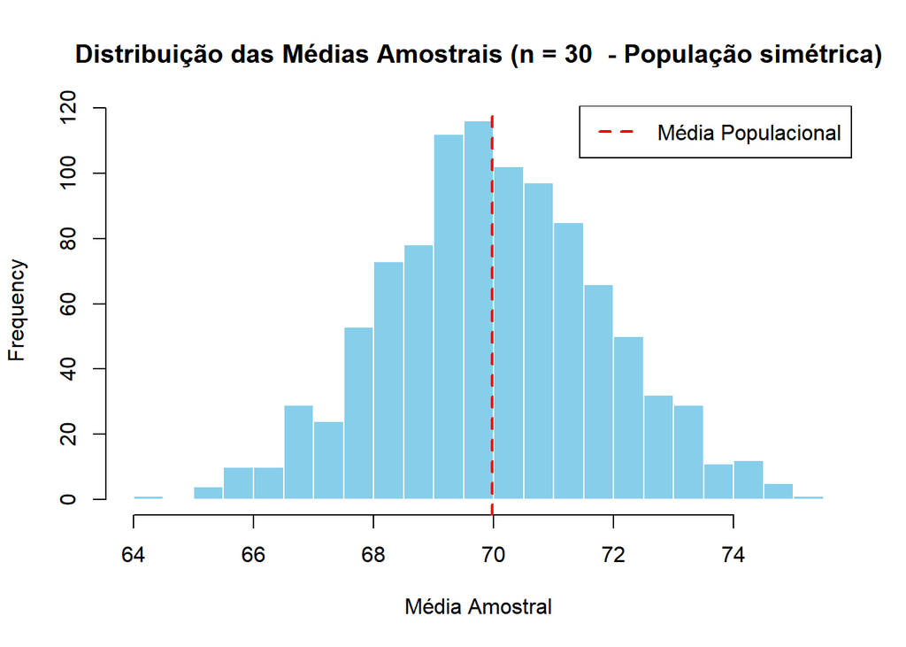

- A média das amostras tende a ser a média da população
- A distribuição dessas médias tende ao formato normal (graças ao Teorema Central do Limite), mesmo com amostras de tamanho moderado (n = 30)

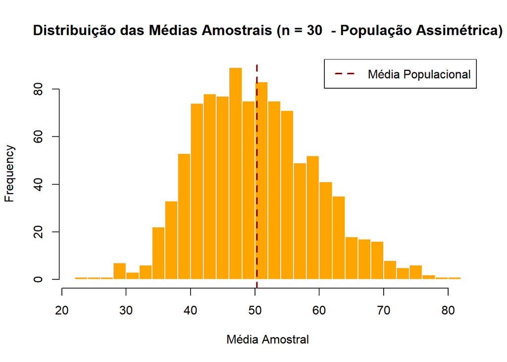

- A população original é assimétrica — puxa mais valores baixos
- Mesmo assim, a distribuição das médias amostrais vai parecer quase normal
- Isso acontece porque, mesmo com uma população assimétrica, a média das amostras tende a se distribuir normalmente se o tamanho da amostra for suficiente

## 2.3 Comportamento das distribuições amostrais

A média das amostras se aproxima da média real da população, mesmo com diferentes tipos de distribuição.

A distribuição das médias amostrais tende a ser normal (formato de sino), mesmo quando a população não é normal — isso é garantido pelo Teorema Central do Limite.

Isso mostra que podemos usar técnicas paramétricas mesmo em contextos reais com populações assimétricas, desde que o tamanho da amostra seja razoável.

# 3 Conclusão

Logo se faz imprescindível o uso das distribuições para cálculos estatísticos, uma vez que é possível medir variações dentro de grupos, e com combinações entre essas amostras é possível tirar conclusões que podemos utilizar para entender certo comportamento de um grupo, comparações, previsões e conclusões sobre determinados dados